# National Cancer Stats Notebook

Some R code to reproduce some of the statistics in http://www.cancerresearchuk.org/health-professional/cancer-statistics/statistics-by-cancer-type/myeloma in a reproducable / rerunnable way for each cancer type in http://www.cancerresearchuk.org/health-professional/cancer-statistics/statistics-by-cancer-type.

## Attach Libraries

```r
# connection for SQL Server
library(RODBC)
# for data manipuation
library(dplyr)
# for outputting tables in this notebook
library(knitr)
# for charts
library(ggplot2)
# for branding
library(grid)
library(CRUKBrand)
# for highcharts (also requires dplyr)
library(highcharter)
library(tidyr)
```

## Fetch Data

The following are some basic queries for national cancer stats data. Some more complex logic could be done using SQL, but to keep the logic in one place and prevent return trips to the database, the aggregation and filtering is done later using dplyr.

The base year for the data below is 2017 (the data has already been subsetted in SQL Server for performance reasons).

```r
channel <- odbcConnect("cStream", uid="cstream_admin@cstream.database.windows.net", pwd=.rs.askForPassword("Enter password:"));
#get everything in fairly raw way - note could have got male/female as separate measures here rather than using dplyr later
incidence <- sqlQuery(channel, "
SELECT
  cs.LEVEL3_CANCER_SITE_CODE,
  ar.AGE_RANGE,
  ar.AGE_FROM,
  y.YEAR,
  g.GENDER_CODE,
  g.GENDER_DESC,
  SUM(f.INCIDENCE_COUNT) as INCIDENCE_COUNT
FROM
  [dbo].[FCT_INCIDENCE_2017] f
  INNER JOIN [dbo].[DIM_CANCER_SITE] cs ON f.[CANCER_SITE_WID] = cs.[CANCER_SITE_WID]
  INNER JOIN [dbo].[DIM_YEAR] y ON f.[INCIDENCE_YEAR_WID] = y.[YEAR_WID]
  INNER JOIN [dbo].[DIM_AGE_RANGE] ar ON f.[AGE_RANGE_WID] = ar.[AGE_RANGE_WID]
  INNER JOIN [dbo].[DIM_GENDER] g ON f.[GENDER_WID] = g.[GENDER_WID]
WHERE
  cs.LEVEL1_CANCER_SITE_CODE = 'C00-C97: All Cancers'
GROUP BY
  cs.LEVEL3_CANCER_SITE_CODE,
  ar.AGE_RANGE,
  ar.AGE_FROM,
  y.YEAR,
  g.GENDER_CODE,
  g.GENDER_DESC
");
population <- sqlQuery(channel, "
SELECT
  ar.AGE_RANGE,
  ar.AGE_FROM,
  y.YEAR,
  geo.REGION_CODE,
  g.GENDER_CODE,
  g.GENDER_DESC,
  SUM(f.POPULATION_COUNT) as POPULATION_COUNT
FROM
  dbo.FCT_POPULATION_2017 f
  INNER JOIN dbo.DIM_YEAR y ON f.POPULATION_YEAR_WID = y.YEAR_WID
  INNER JOIN dbo.DIM_GEOGRAPHY geo ON f.REGION_WID = geo.REGION_WID
  INNER JOIN dbo.DIM_AGE_RANGE ar ON f.AGE_RANGE_WID = ar.AGE_RANGE_WID
  INNER JOIN dbo.DIM_GENDER g ON f.GENDER_WID = g.GENDER_WID
GROUP BY
  ar.AGE_RANGE,
  ar.AGE_FROM,
  y.YEAR,
  geo.REGION_CODE,
  g.GENDER_CODE,
  g.GENDER_DESC
");
close(channel);
```

Display first few rows of data

```r
kable(head(incidence))
```

| LEVEL3_CANCER_SITE_CODE | AGE_RANGE | AGE_FROM | YEAR | GENDER_CODE | GENDER_DESC | INCIDENCE_COUNT |
| --- | --- | --- | --- | --- | --- | --- |
| Other Respiratory and Intrathoracic Organs (C39) | 05 to 09 | 5 | 1982 | M | Male | 0 |
| Testis (C62) | 15 to 19 | 15 | 1996 | M | Male | 39 |
| Oesophagus (C15) | 25 to 29 | 25 | 2012 | M | Male | 4 |
| Melanoma Skin Cancer (C43) | 55 to 59 | 55 | 1992 | M | Male | 188 |
| Anus (C21) | 60 to 64 | 60 | 2001 | M | Male | 33 |
| Pancreas (C25) | 65 to 69 | 65 | 1993 | M | Male | 498 |

```r
kable(head(population))
```

| AGE_RANGE | AGE_FROM | YEAR | REGION_CODE | GENDER_CODE | GENDER_DESC | POPULATION_COUNT |
| --- | --- | --- | --- | --- | --- | --- |
| 0 to 04 | 0 | 1997 | Northern Ireland | F | Female | 59354 |
| 55 to 59 | 55 | 1981 | England | M | Male | 1330700 |
| 20 to 24 | 20 | 2011 | Scotland | M | Male | 182095 |
| 50 to 54 | 50 | 2001 | Scotland | F | Female | 176945 |
| 75 to 79 | 75 | 1987 | Scotland | M | Male | 58006 |
| 75 to 79 | 75 | 1982 | Scotland | F | Female | 96737 |

## Set Variables

These top level variables could be created as parameters in a function in a future iteration.

```r
l3_code <- 'Bone (C40-C41)'
incidence_year <- 2014
min_incidence_year <- incidence_year - 2
```

## Incidence by Sex and UK Country

The following section filters, aggregates, ranks etc. using dplyr https://cran.rstudio.com/web/packages/dplyr/vignettes/introduction.html

Filters have been specified to match the website mostly using guesswork just for the purposes of a demo - there will be other groupings/exclusions to be factored in.

The dplyr functions have been written individually so can be demo’d/debugged, but chaining (%>%) could be used instead.

```r
# add gender measures upfront - will make formulas on ranking by gender simpler later
incidence_base <- mutate(incidence,
                         INCIDENCE_COUNT_M = ifelse(GENDER_CODE== 'M', INCIDENCE_COUNT, 0),
                         INCIDENCE_COUNT_F = ifelse(GENDER_CODE== 'F', INCIDENCE_COUNT, 0))
# get latest incidence for all cancer types
latest_incidence <- filter(incidence_base,
                           YEAR == incidence_year,
                           LEVEL3_CANCER_SITE_CODE != 'Cancer of Unknown Primary (C77-C80)')
# group by cancer site code so can rank etc.
by_l3 <- group_by(latest_incidence,
                  LEVEL3_CANCER_SITE_CODE)
# aggregate measures defined above by site code
agg_l3 <- summarise(by_l3,
                    INCIDENCE_COUNT=sum(INCIDENCE_COUNT),
                    INCIDENCE_COUNT_M=sum(INCIDENCE_COUNT_M),
                    INCIDENCE_COUNT_F=sum(INCIDENCE_COUNT_F))
# rank and calc percentages of totals for all, male, and female
ranked_l3 <- mutate(agg_l3,
               L3_RANK = min_rank(desc(INCIDENCE_COUNT)),
               L3_PC = round(100* INCIDENCE_COUNT / sum(agg_l3$INCIDENCE_COUNT), 2),
               L3_RANK_M = min_rank(desc(INCIDENCE_COUNT_M)),
               L3_PC_M = round(100* INCIDENCE_COUNT_M / sum(agg_l3$INCIDENCE_COUNT_M), 2),
               L3_RANK_F = min_rank(desc(INCIDENCE_COUNT_F)),
               L3_PC_F = round(100* INCIDENCE_COUNT_F / sum(agg_l3$INCIDENCE_COUNT_F, 2)))
```

Display sample of results

```r
# get rank of cancer site so only see 5 rows either side
cancer_rank <- ranked_l3[ranked_l3$LEVEL3_CANCER_SITE_CODE == l3_code,]$L3_RANK
cancer_results <- ranked_l3 %>% select(LEVEL3_CANCER_SITE_CODE, INCIDENCE_COUNT, L3_RANK, L3_PC) %>% arrange(desc(INCIDENCE_COUNT)) %>% filter(L3_RANK >= cancer_rank - 5 & L3_RANK <= cancer_rank + 5)
# bold the cancer site code - harder than it should be. Displaying decent HTML tables could be a problem here
cancer_results$LEVEL3_CANCER_SITE_CODE <- as.character(cancer_results$LEVEL3_CANCER_SITE_CODE)
cancer_results$LEVEL3_CANCER_SITE_CODE[cancer_results$LEVEL3_CANCER_SITE_CODE == l3_code] <- paste("**", l3_code, "**", sep="")
# display a sample of results so far
kable(cancer_results, caption="L3 Cancer Sites Ranked by Incidence")
```

| LEVEL3_CANCER_SITE_CODE | INCIDENCE_COUNT | L3_RANK | L3_PC |
| --- | --- | --- | --- |
| Other Biliary Tract (C24) | 1159 | 29 | 0.24 |
| Gallbladder (C23) | 975 | 30 | 0.20 |
| Retroperitoneum and Peritoneum (C48) | 765 | 31 | 0.16 |
| Eye (C69) | 750 | 32 | 0.16 |
| Penis (C60) | 632 | 33 | 0.13 |
| **Bone (C40-C41)** | 579 | 34 | 0.12 |
| Other Digestive Organs (C26) | 519 | 35 | 0.11 |
| Malignant Immunoproliferative Diseases (C88) | 432 | 36 | 0.09 |
| Other and Ill-Defined Sites (C76) | 294 | 37 | 0.06 |
| Vagina (C52) | 254 | 38 | 0.05 |
| Adrenal Gland (C74) | 210 | 39 | 0.04 |

Now can do some calculations for the cancer type we’re looking at and display some sample figures.

```r
# logic to get the row for the cancer type interested in
L <- ranked_l3$LEVEL3_CANCER_SITE_CODE == l3_code
cancer_cases <- format(ranked_l3[L,]$INCIDENCE_COUNT, big.mark=",")
cancer_rank <- paste(ranked_l3[L,]$L3_RANK, "th", sep="")
cancer_pc <- paste(ranked_l3[L,]$L3_PC, "%", sep="")
cancer_cases_m <- format(ranked_l3[L,]$INCIDENCE_COUNT_M, big.mark=",")
cancer_rank_m <- paste(ranked_l3[L,]$L3_RANK_M, "th", sep="")
cancer_pc_m <- paste(ranked_l3[L,]$L3_PC_M, "%", sep="")
cancer_pc_tot_m <- paste(round(100*ranked_l3[L,]$INCIDENCE_COUNT_M / ranked_l3[L,]$INCIDENCE_COUNT), "%", sep="")
cancer_cases_f <- format(ranked_l3[L,]$INCIDENCE_COUNT_F, big.mark=",")
cancer_rank_f <- paste(ranked_l3[L,]$L3_RANK_F, "th", sep="")
cancer_pc_f <- paste(ranked_l3[L,]$L3_PC_F, "%", sep="")
cancer_pc_tot_f <- paste(round(100*ranked_l3[L,]$INCIDENCE_COUNT_F / ranked_l3[L,]$INCIDENCE_COUNT), "%", sep="")
cat(
  paste("* ", cancer_cases, " new cases of ", l3_code, ", ", incidence_year, ", UK", sep=""),
  paste("\n* ", l3_code, " is the ", cancer_rank, " most common cancer in the UK (", incidence_year, ")", sep=""),
  paste("\n* ", l3_code, " accounts for around ", cancer_pc, " of all new cases", sep=""),
  paste("\n* ", "In males, it is the ", cancer_rank_m, " most common cancer (", cancer_pc_m, " of all male cases)", sep=""),
  paste("\n* ", "In females, it is the ", cancer_rank_f, " most common cancer (", cancer_pc_f, " of all female cases)", sep=""),
  paste("\n* ", "In ", incidence_year, ", there were ", cancer_cases, " new cases of ", l3_code, " in the UK: ", cancer_cases_m, " (", cancer_pc_tot_m, ") in men and ", cancer_cases_f, " (", cancer_pc_tot_f, ") in women", sep=""))
```

```
* 579 new cases of Bone (C40-C41), 2014, UK
* Bone (C40-C41) is the 34th most common cancer in the UK (2014)
* Bone (C40-C41) accounts for around 0.12% of all new cases
* In males, it is the 28th most common cancer (0.12% of all male cases)
* In females, it is the 32th most common cancer (0% of all female cases)
* In 2014, there were 579 new cases of Bone (C40-C41) in the UK: 305 (53%) in men and 274 (47%) in women
```

# Incidence by Age

For age, going to work with gender breakdown a little differently. Eventually we want a bar chart with bars for both male and female - so we will leave gender as a grouping rather than creating the indiviudal measures in the previous section which were useful for ranking.

First filter the data for a single cancer type (no ranking/context required here) and for a 3 year range.

```r
age_incidence <- filter(incidence_base,
                           YEAR >= min_incidence_year,
                           YEAR <= incidence_year,
                           LEVEL3_CANCER_SITE_CODE == l3_code)
kable(head(age_incidence))
```

| LEVEL3_CANCER_SITE_CODE | AGE_RANGE | AGE_FROM | YEAR | GENDER_CODE | GENDER_DESC | INCIDENCE_COUNT | INCIDENCE_COUNT_M | INCIDENCE_COUNT_F |
| --- | --- | --- | --- | --- | --- | --- | --- | --- |
| Bone (C40-C41) | 05 to 09 | 5 | 2013 | M | Male | 11 | 11 | 0 |
| Bone (C40-C41) | 10 to 14 | 10 | 2012 | M | Male | 26 | 26 | 0 |
| Bone (C40-C41) | 35 to 39 | 35 | 2013 | M | Male | 11 | 11 | 0 |
| Bone (C40-C41) | 75 to 79 | 75 | 2014 | M | Male | 8 | 8 | 0 |
| Bone (C40-C41) | 90 to 94 | 90 | 2013 | M | Male | 5 | 5 | 0 |
| Bone (C40-C41) | 95+ | 95 | 2014 | M | Male | 0 | 0 | 0 |

Next, need to aggregate in two passes so can calculate the average incidence per year.

```r
# group by gender, year and age range - so can sum before average
by_gender_age_year <- group_by(age_incidence,
                        GENDER_DESC,
                        AGE_RANGE,
                        YEAR)
# aggregate measures defined above by site code
agg_gender_age_year <- summarise(by_gender_age_year,
                                 INCIDENCE_COUNT=sum(INCIDENCE_COUNT))
# now group by gender and age range alone, and average over the three years
by_gender_age <- group_by(agg_gender_age_year,
                         GENDER_DESC,
                         AGE_RANGE)
# calculate average per age range and gender
agg_gender_age <- summarise(by_gender_age,
                    AVG_INCIDENCE_COUNT=round(mean(INCIDENCE_COUNT)))
kable(head(agg_gender_age))
```

| GENDER_DESC | AGE_RANGE | AVG_INCIDENCE_COUNT |
| --- | --- | --- |
| Female | 0 to 04 | 3 |
| Female | 05 to 09 | 10 |
| Female | 10 to 14 | 21 |
| Female | 15 to 19 | 23 |
| Female | 20 to 24 | 16 |
| Female | 25 to 29 | 14 |

Now can plot using ggplot.

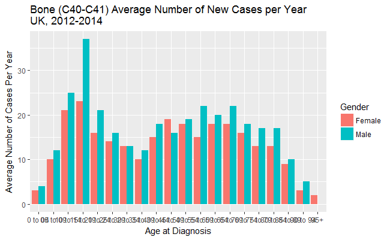

```r
plot_title <- paste(l3_code, " Average Number of New Cases per Year\nUK, ", min_incidence_year, "-", incidence_year,  sep="")
ggplot(data=agg_gender_age, aes(x=AGE_RANGE, y=AVG_INCIDENCE_COUNT, fill=GENDER_DESC)) +
  geom_bar(stat="identity", position=position_dodge()) +
  labs(title=plot_title, x="Age at Diagnosis", y="Average Number of Cases Per Year", fill="Gender")
```

Looks pretty ugly! In the original, the text labels are wrapped. TODO: brand and make this better. TODO: age-specific incidence rates (need population).

For some of the other stats, need to the same aggregations as above but without gender. This is so can average for persons. There is probably a better way to do this.

[figure not shown]

```r
plot_title <- paste(l3_code, " Average Number of New Cases per Year, UK, ", min_incidence_year, "-", incidence_year,  sep="")
p <- ggplot(data=agg_gender_age, aes(x=AGE_RANGE, y=AVG_INCIDENCE_COUNT, fill=GENDER_DESC)) +
  geom_bar(stat="identity", position=position_dodge()) +
  labs(title=plot_title, x="Age at Diagnosis", y="Average Number of Cases Per Year", fill="Gender")
grid.newpage()
g <- applyCRUKBrand(p)
grid.draw(g)
```

Still ugly, let’s have another go.

```r
#highchart() %>%
#  hc_add_series(data=agg_gender_age$INCIDENCE_COUNT, type="column", name="Average Number of Cases Per Year") %>%
#  hc_yAxis(title=list(text="Average Number of Cases Per Year")) %>%
#  hc_xAxis(categories=agg_gender_age$AGE_RANGE)
hchart(agg_gender_age, "column", x = AGE_RANGE, y = AVG_INCIDENCE_COUNT, group = GENDER_DESC) %>%
  hc_title(text=paste(l3_code, "Average Number of New Cases per Year")) %>%
  hc_subtitle(text=paste("UK", min_incidence_year, "-", incidence_year)) %>%
  hc_yAxis(title=list(text="Average Number of Cases Per Year")) %>%
  hc_xAxis(title=list(text="Age Range"))
```

[interactive chart not shown]

```r
# group by year and age range - so can sum before average
by_age_year <- group_by(age_incidence,
                        AGE_RANGE,
                        AGE_FROM,
                        YEAR)
# aggregate measures defined above by site code
agg_age_year <- summarise(by_age_year,
                          INCIDENCE_COUNT=sum(INCIDENCE_COUNT))
# now group by gender and age range alone, and average over the three years
by_age <- group_by(agg_age_year,
                   AGE_RANGE,
                   AGE_FROM)
# calculate average per age range and gender
agg_age <- summarise(by_age,
                     AVG_INCIDENCE_COUNT=round(mean(INCIDENCE_COUNT)))
kable(head(agg_age))
```

| AGE_RANGE | AGE_FROM | AVG_INCIDENCE_COUNT |
| --- | --- | --- |
| 0 to 04 | 0 | 8 |
| 05 to 09 | 5 | 22 |
| 10 to 14 | 10 | 46 |
| 15 to 19 | 15 | 59 |
| 20 to 24 | 20 | 37 |
| 25 to 29 | 25 | 29 |

The next section is nonsense as not using age standardised rates, but just shows some of the figures that can be used to construct the narrative (e.g. see http://www.cancerresearchuk.org/health-professional/cancer-statistics/statistics-by-cancer-type/bone-sarcoma/incidence#heading-One).

So can see the data without gender:

```r
plot_title = paste(l3_code, " Average Number of New Cases per Year\nUK, ", min_incidence_year, "-", incidence_year,  sep="")
hchart(agg_age, "column", x = AGE_RANGE, y = AVG_INCIDENCE_COUNT) %>%
  hc_title(text="Average Number of New Cases per Year") %>%
  hc_subtitle(text=paste("UK", min_incidence_year, "-", incidence_year)) %>%
  hc_yAxis(title=list(text="Average Number of Cases Per Year")) %>%
  hc_xAxis(title=list(text="Age Range"))
```

[interactive chart not shown]

```r
NA
```

And some information (again - not using age standardised rates):

```r
# want to work out the peak, so sort and take first row, then get value of age range
peak_age <- arrange(agg_age, desc(INCIDENCE_COUNT))[1, ]
peak_age_range <- as.character(peak_age$AGE_RANGE)
# want to work out the first age where more than half the cases are over that age
# need a cumulative sum over the age descending as a percentage of the total
# (could also be done using percentiles)
half_age <- agg_age %>% arrange(desc(AGE_FROM))
half_age$INCIDENCE_COUNT_PC = 100 * cumsum(half_age$INCIDENCE_COUNT) / sum(half_age$INCIDENCE_COUNT)
# get the first row where over 50%
half_age_50 <- (half_age %>% filter(INCIDENCE_COUNT_PC > 50))[1,]
age_50_age_from = as.character(half_age_50$AGE_FROM)
age_50_pc = round(as.numeric(half_age_50$INCIDENCE_COUNT_PC), 2)
# output findings
cat(
  cat("Average incidence by age range: ", mean(agg_age$INCIDENCE_COUNT)),
  cat("\nStandard deviation of incidence by age range: ", sd(agg_age$INCIDENCE_COUNT)),
  cat("\nPeak age range: ", peak_age_range),
  cat("\nOn average each year more than half (", age_50_pc, "%) of cases were diagnosed in people aged ", age_50_age_from, " and over", sep="")
)
```

```
Average incidence by age range:  29.55
Standard deviation of incidence by age range:  13.60352
Peak age range:  15 to 19
On average each year more than half (52.57%) of cases were diagnosed in people aged 45 and over
```